# Sports Solution - Rugby Analytics

## Introduction

We offer a some analytics solution, all your rugby analytics managed on one platform. From injuries detection, players analytics, training optimization, player selection or real time match optimization.

We will streamline your data management while automatically updating your website, mobile application with new analytics and Game Schedule in realtime.

We have huge implementation experience on different software solutiont at every level.

Our approach is iterative, we deliver just the solution needed to target all our energy in the quality our work.

## Case study : Super Rugby Unions

We don’t need to explain what is this extraordinary Rugby championship. We cover all the matchs and players data from 2014 to 2016. This domain corresponds to a global view of rugby analytics. It doesn’t cover training or medical analytics that is day to day life of a team. Our experience can be mixed to more particular information and cover more analytics. The goals it to show analytics use case. From simple view as characteristics of players or to detect futur injuries or performance.

### Use case : Compare your Players characteristics

[figure not shown]

There are more than 1000 players identified in the Super Rugby union. This data is composed by beginner or experienced players. It represent more than 16 competition matches.

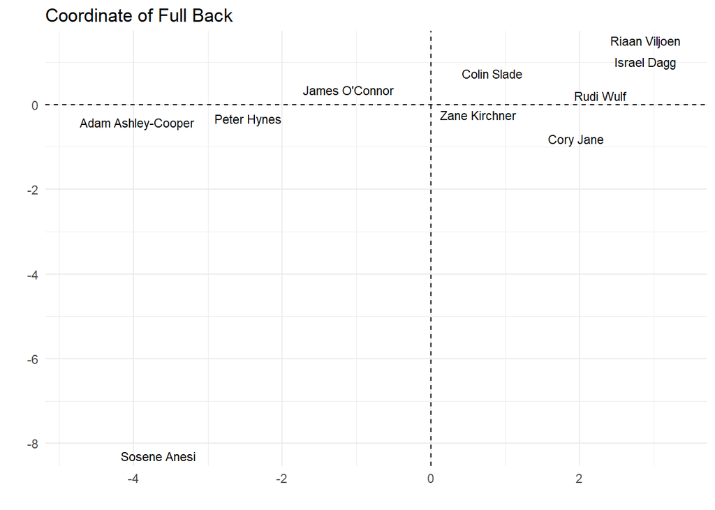

[output not shown]

[output cut: 49 more lines]

[output not shown]

[output cut: 77 more lines]

[output not shown]

```
## [1] 125 100
```

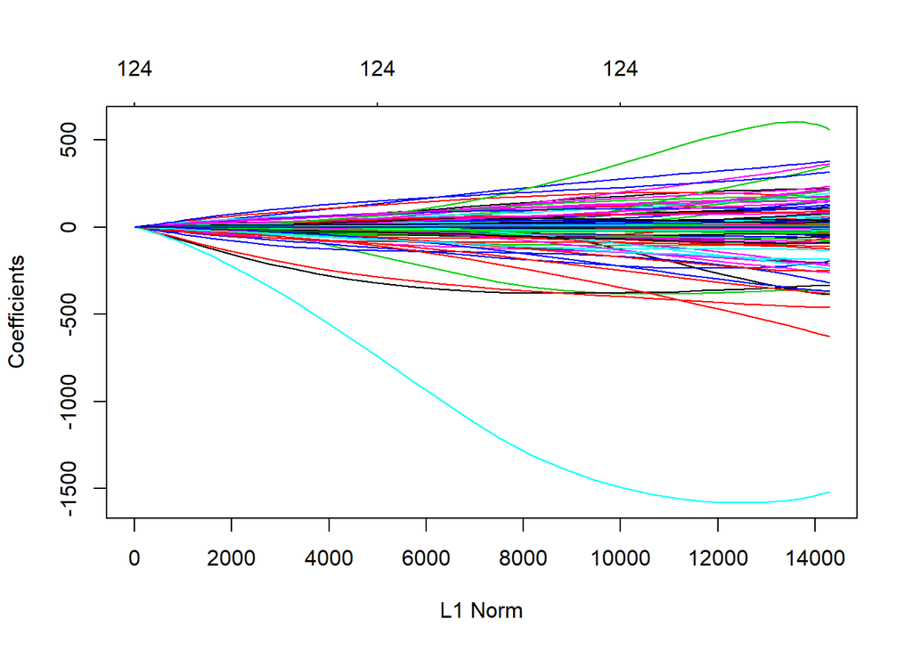

```
## [1] 32
```

```
## [1] 24
```

```
##     581
## 27.5105
```

```
##      581
## 22.05683
```

### Use case : Team selection

The subject of team selection is more than simple analysis. Because the impact of a player or a group of player needs a modelisation of a match. In this use case, we have selected the Super Rugby match of : Hurricanes agains Sharks in 2015.

In this match, Hurricanes wins 32 - 24. The team of Hurricanes is important. A lot of great players plays in this team. hurricanes comes from Wellington in New Zealand. The Sharks comes from Durban in South Africa.

[output not shown]

```
## [1] 4.060781
```

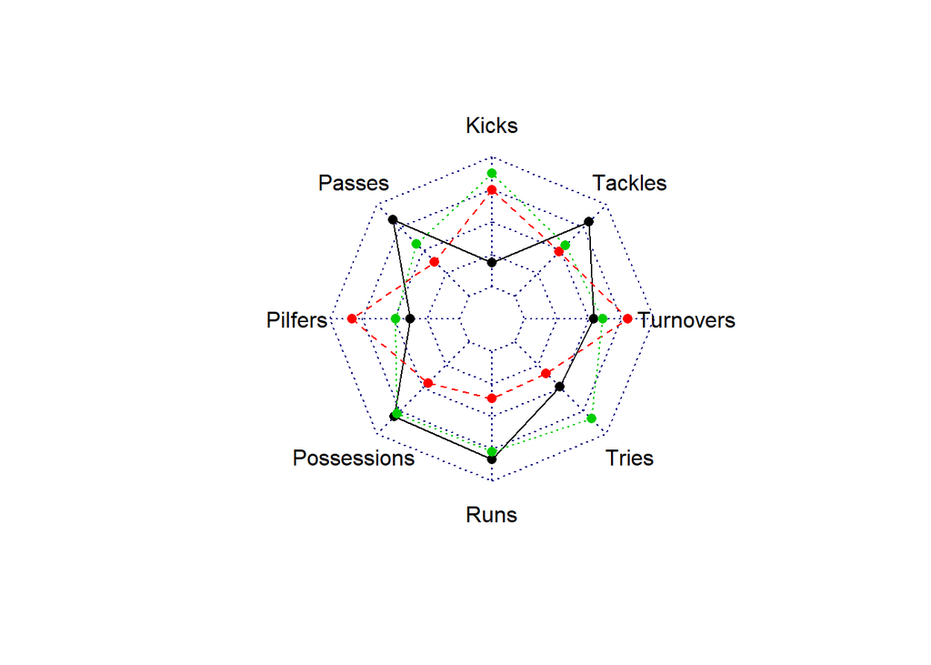

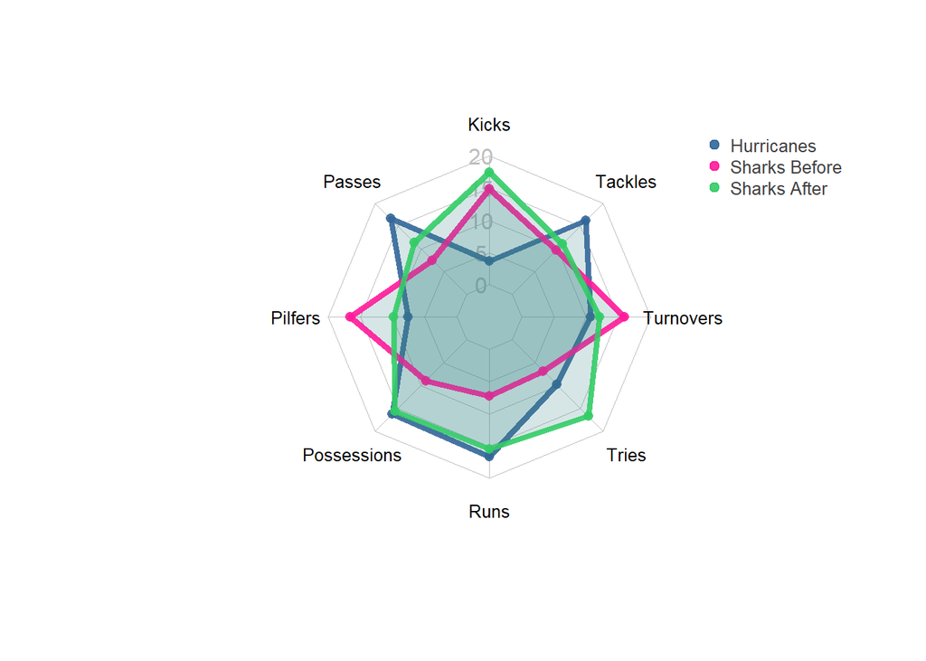